# hypergraph_measures(): structure without a projection

honets

2026-08-26

## The analytic question

Graph descriptives — degree, density, clustering — all assume relations come in pairs. Applied to a projected hypergraph they answer questions about the projection rather than about the data.

`hypergraph_measures()` computes the equivalents directly on the hypergraph: how many groups is each node in, how large are the groups, and how much do the groups overlap. The last of these has no graph analogue at all, and is usually the most informative.

```r
library(honets)
hg <- group_hypergraph(human_long, member = "code", group = "session_id")
m <- hypergraph_measures(hg)
m
```

```
Hypergraph measures: 9 nodes, 429 hyperedges
  Density:                0.7293
  Mean edge size:         6.56
  Pairwise participation: 1.0000

  Hyperdegree:    min=218  med=268.0  max=423
  Node strength:  min=1666.0  med=1967.0  max=2796.0
  Edge sizes:     min=1  med=7.0  max=9

Intersection profile (pair counts by overlap size):
  overlap_0   : 96
  overlap_1   : 2960
  overlap_2   : 3235
  overlap_3   : 10827
  overlap_4   : 18272
  overlap_5   : 20355
  overlap_6   : 15746
  overlap_7   : 10601
  overlap_8   : 6554
  overlap_9   : 3160
```

```r
library(cograph)
```

## Per-node measures

```r
as.data.frame(m, sort_by = "hyperdegree")
```

```
       node hyperdegree node_strength max_edge_size
1   Command         423          2796             9
2   Specify         415          2786             9
3 Interrupt         393          2691             9
4   Request         353          2447             9
5   Correct         268          1967             9
6   Inquire         261          1949             9
7 Frustrate         252          1911             9
8    Refine         233          1773             9
9    Verify         218          1666             9
```

- **`hyperdegree`** — how many hyperedges contain this node. Command appears in 423 of 429 sessions.
- **`node_strength`** — the summed incidence weight. On a binary incidence this is a weighted count; the gap between it and hyperdegree tells you how much the weights matter.
- **`max_edge_size`** — the largest group this node ever belonged to. All 9 here, because every code appears in at least one nine-code session.

The spread is narrow: 423 down to 218, a ratio under 2. Every action is present in most sessions, so **hyperdegree does not discriminate strongly** — worth knowing before building an argument on it. Compare with `hypergraph_centrality()`, which uses the overlap structure rather than raw membership counts.

## Whole-hypergraph measures

```r
as.data.frame(m, what = "global")
```

```
                 measure       value
1                n_nodes   9.0000000
2           n_hyperedges 429.0000000
3                density   0.7293447
4          avg_edge_size   6.5641026
5 pairwise_participation   1.0000000
```

**Density 0.729** is the fraction of possible (node, hyperedge) memberships that exist — a hypergraph analogue of graph density, and high here because sessions use most of the code set.

**Pairwise participation 1.0** is the one to notice. It is the fraction of node *pairs* that co-occur in at least one hyperedge, and it is at ceiling: every pair of codes shares a session. That is precisely why a pairwise projection of these data is uninformative — it would be the complete graph.

## Hyperedge sizes

```r
as.data.frame(m, what = "edges", top = 5)
```

```
  hyperedge size
1        h1    6
2        h2    3
3        h3    9
4        h4    9
5        h5    5
```

```r
table(as.data.frame(m, what = "edges")$size)
```

```
 1  2  3  4  5  6  7  8  9
 5  3 20 32 62 77 75 75 80
```

## Seeing the structure

The per-node table becomes a picture two ways: the co-membership weights as a heatmap, and the projected network itself. The heatmap is the honest one — it shows the pairwise weights the measures are computed from without implying the hypergraph *was* a graph.

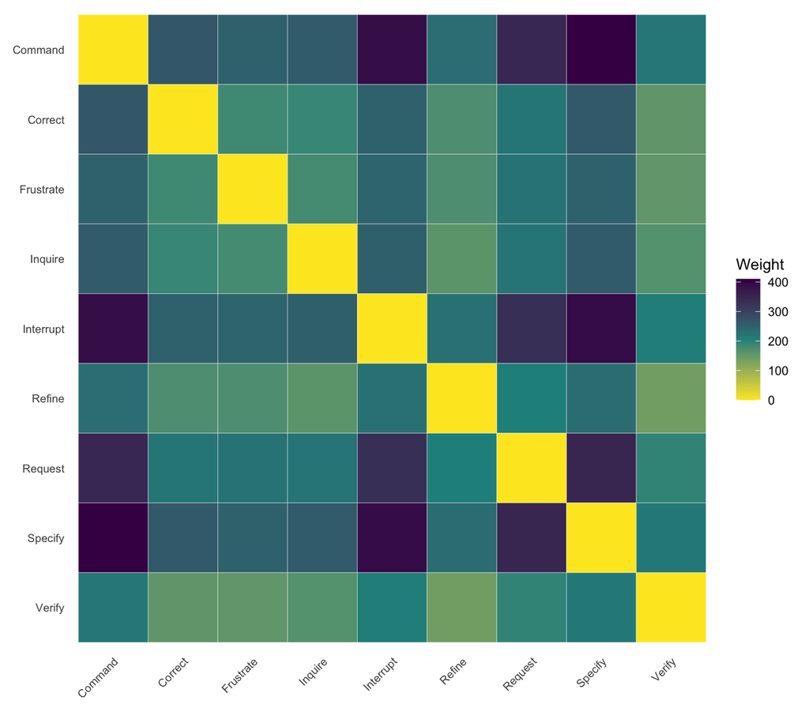

```r
plot_heatmap(clique_expansion(hg))
```

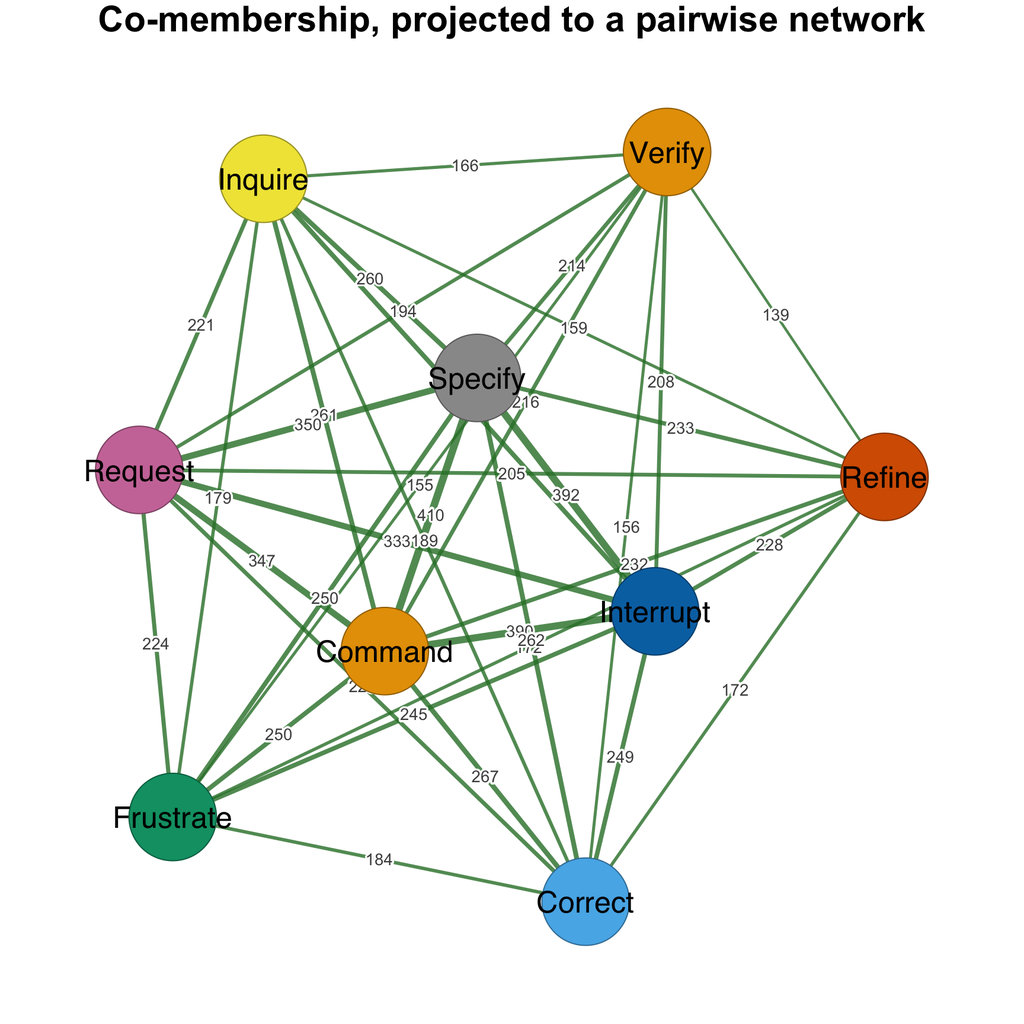

```r
splot(clique_expansion(hg), minimum = 0.05,
      title = "Co-membership, projected to a pairwise network")
```

## The intersection profile

The most distinctively hypergraph-shaped output, shown by `print()`: how many *pairs of hyperedges* share exactly k members.

```r
m
```

```
Hypergraph measures: 9 nodes, 429 hyperedges
  Density:                0.7293
  Mean edge size:         6.56
  Pairwise participation: 1.0000

  Hyperdegree:    min=218  med=268.0  max=423
  Node strength:  min=1666.0  med=1967.0  max=2796.0
  Edge sizes:     min=1  med=7.0  max=9

Intersection profile (pair counts by overlap size):
  overlap_0   : 96
  overlap_1   : 2960
  overlap_2   : 3235
  overlap_3   : 10827
  overlap_4   : 18272
  overlap_5   : 20355
  overlap_6   : 15746
  overlap_7   : 10601
  overlap_8   : 6554
  overlap_9   : 3160
```

96 pairs of sessions share no codes at all; 20,355 pairs share five. Read as a distribution, it says these sessions are **highly overlapping** — the typical pair has five codes in common. A collection of specialised, disjoint groups would put its mass at the low end instead.

This is a property of the *set system*. No pairwise projection retains it.

## A contrasting example

```r
disjoint <- group_hypergraph(
  data.frame(member = c("A","B","C","D","E","F"),
             grp    = c("g1","g1","g2","g2","g3","g3"),
             stringsAsFactors = FALSE),
  member = "member", group = "grp")
md <- hypergraph_measures(disjoint)
as.data.frame(md, what = "global")
```

```
                 measure value
1                n_nodes   6.0
2           n_hyperedges   3.0
3                density   0.2
4          avg_edge_size   2.0
5 pairwise_participation   0.2
```

```r
md
```

```
Hypergraph measures: 6 nodes, 3 hyperedges
  Density:                0.2000
  Mean edge size:         2.00
  Pairwise participation: 0.2000

  Hyperdegree:    min=1  med=1.0  max=1
  Node strength:  min=2.0  med=2.0  max=2.0
  Edge sizes:     min=2  med=2.0  max=2

Intersection profile (pair counts by overlap size):
  overlap_0   : 3
```

## On an inferred hypergraph

```r
set.seed(1)
mat <- matrix(runif(100), 10, 10)
mat <- (mat + t(mat)) / 2
diag(mat) <- 0
dimnames(mat) <- list(LETTERS[1:10], LETTERS[1:10])
mi <- hypergraph_measures(build_hypergraph(mat, threshold = 0.5))
as.data.frame(mi, what = "global")
```

```
                 measure      value
1                n_nodes 10.0000000
2           n_hyperedges 39.0000000
3                density  0.2384615
4          avg_edge_size  2.3846154
5 pairwise_participation  0.5333333
```

```r
as.data.frame(mi, sort_by = "hyperdegree", top = 4)
```

```
  node hyperdegree node_strength max_edge_size
1    E          13            33             3
2    A          12            30             3
3    D          11            28             3
4    I          11            28             3
```

Clique-derived hypergraphs have much lower density, because most hyperedges are size 2 or 3 rather than spanning most of the node set.

## What to do next

- **`hypergraph_centrality()`** — ranking nodes, where hyperdegree does not separate them.
- **`hypergraph_cluster()`** — grouping nodes using the hypergraph’s random walk.
- **`clique_expansion()`** — the projection, and what it costs.
- **`q_analysis()`** — the overlap question again, in the simplicial family, where subset closure is assumed.

## References

- Lee, G., Choe, M., & Shin, K. (2024). A survey on hypergraph representation, learning and mining. *Data Mining & Knowledge Discovery*, 37, 1-39.
- Do, M. T., Yoon, S., Hooi, B., & Shin, K. (2020). Structural patterns and generative models of real-world hypergraphs. *KDD 2020*, 176-186.